# DM05

**演習では，他人のデバイスに触らない．自分のデバイスを，他人に触らせない．**

**新しいノートブックは作らない．**前回作業したノートブックは，Google Driveの「マイドライブ/Colab Notebooks」に保存されているはず．それを開いて再開する．

結果を提示しているのは，計算が正しいことを確認してもらうためである．結果の形式を完全に同じにする必要はない．

## 1 準備

```
!pip install japanize_matplotlib | tail -n 1
```

### 1.1 使用するパッケージ

```python
import japanize_matplotlib
import numpy as np
import pandas as pd
import seaborn as sns
import statsmodels.api as sm
from sklearn import metrics
from sklearn.linear_model import LinearRegression
from sklearn.model_selection import cross_val_score, GridSearchCV, LeaveOneOut
from sklearn.neighbors import KNeighborsRegressor
from statsmodels.stats.weightstats import CompareMeans, DescrStatsW
from sympy import *
```

### 1.2 使用するデータ

#### 1.2.1 例：`data2`（教科書7.1, 7.2）

以下で，`data2`として用いるデータを用意する。

```python
data2 = sm.datasets.get_rdataset('cars', 'datasets').data
data2.head()
```

```
##    speed  dist
## 0      4     2
## 1      4    10
## 2      7     4
## 3      7    22
## 4      8    16
```

[figure not shown]

#### 1.2.2 例：`data3`

以下で，`data3`として用いるデータを用意する。データはhttps://www.data.jma.go.jp/cpdinfo/temp/an_wld.htmlで公開されている。ここでは，CSVファイルを直接データフレームとして読み込み，「年」と「世界全体」だけを残す．

```python
tmp = pd.read_csv('https://www.data.jma.go.jp/cpdinfo/temp/list/csv/an_wld.csv', encoding='Shift_JIS')
print(tmp.head())
```

```
##       年  世界全体   北半球   南半球
## 0  1891 -0.78 -0.88 -0.68
## 1  1892 -0.89 -1.00 -0.74
## 2  1893 -0.94 -1.06 -0.79
## 3  1894 -0.86 -0.93 -0.77
## 4  1895 -0.82 -0.95 -0.67
```

```python
data3 = tmp[['年', '世界全体']]
```

**課題** （復習）「年」を入力変数，「世界全体」を出力変数とする。線形回帰分析を行い，回帰係数の推定値を求めよ。世界全体の気温は，100年当たり何℃上昇する傾向にあるか。

**課題** （復習）データの散布図と，このデータに対して線形回帰分析を行ってできるモデルをまとめて可視化せよ。

## 2 K最近傍法（教科書 7.5節）

近傍$K$個の平均を予測値とする方法。パラメータチューニングをやるまでは，近傍の数は5とする（`n_neighbors=5`は省略可）。

### 2.1 `data2`

**課題** `data2`にK最近傍法`KNeighborsRegressor`のモデルを当てはめ，モデルの振る舞いを可視化せよ。可視化する部分のコードを示す。

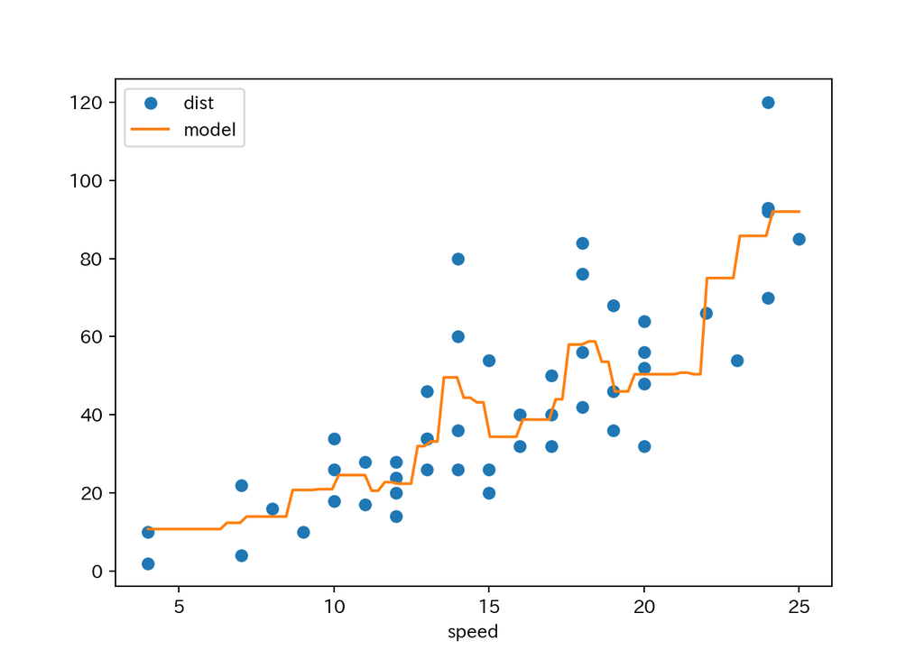

```python
x = data2['speed']
tmp = pd.DataFrame({'speed': np.linspace(min(x), max(x), 100)})
tmp['model'] = model.predict(tmp)

pd.concat([data2, tmp]).plot(x='speed', style=['o', '-']);
```

**課題** RMSEと決定係数を求めよ。

**課題** 次の表を完成させよ。

| モデル | RMSE | 決定係数 |
| --- | --- | --- |
| K最近傍法 | ● | ● |
| 線形回帰分析 | 15.1 | ● |

### 2.2 `data3`

**課題** `data3`にK最近傍法`KNeighborsRegressor`のモデルを当てはめ，モデルの振る舞いを可視化せよ。

**課題** 次の表を完成させよ。

| モデル | RMSE | 決定係数 |
| --- | --- | --- |
| K最近傍法 | ● | ● |
| 線形回帰分析 | 0.158 | ● |

## 3 検証（教科書 7.6節）

### 3.1 `data2`

**課題** `data2`に対する，線形回帰分析とK最近傍法の予測性能を，5分割交差検証で調べて，次のように可視化せよ。性能指標は決定係数（`r2`）とする。

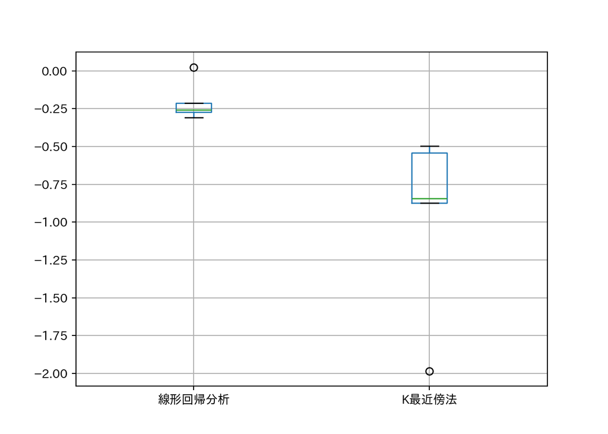

**課題** `data2`に対する，線形回帰分析とK最近傍法の予測性能を，5分割交差検証で調べて，可視化せよ。性能指標はMSE（`neg_mean_squared_error`）とする。

**課題** `data2`に対する，線形回帰分析とK最近傍法の予測性能を，一つ抜き交差検証（leave-one-out cross-validation, LOOCV）で調べて，可視化せよ。性能指標はMSEとする。

$i=1,\dots,n$ とする。

LOOCVでは，$i$ 番目のデータを使わずに訓練したモデルで，$i$ 番目の出力変数の値を予測する。その予測結果を $\hat{y}_{(i)}$ とする。

$\hat{e}_{(i)}:=y_i-\hat{y}_{(i)}$ を予測残差，$\displaystyle\sum_{i=1}^n\hat{e}_{(i)}^2$ をPRESS（predicted residual sum of squares）という。

ここでは，$\displaystyle\sqrt{\frac{1}{n}\sum_{i=1}^n\hat{e}_{(i)}^2}=\sqrt{\mathrm{PRESS}/n}$ を，予測がどのくらい外れるかの目安とする。

**課題** `data2`に対する，線形回帰分析とK最近傍法の，$\displaystyle\sqrt{\mathrm{PRESS}/n}$ を求めよ。ヒント：LOOCVの結果（$n$個の数値）の平均の非負の平方根を求めればよい。（MSEの$-1$倍を求めている場合は，$-1$を掛けてMSEに戻すこと。）

補足♠：一般に，LOOCVのためには $n$ 回の訓練が必要だから，予測残差やPRESSを求めるには，$n$ に比例する時間がかかる。しかし，線形回帰分析は特別で，1回の訓練で，予測残差やPRESSを求められる。ハット行列 $H$ の $(i, i)$ 成分を $h_{ii}$とすると，$\hat{e}_{(i)}=\dfrac{\hat{e}_i}{1-h_{ii}}$ となるからである。参照：Kroeseほか『データサイエンスと機械学習』（東京化学同人, 2022）

これを使って，線形回帰分析の $\displaystyle\sqrt{\mathrm{PRESS}/n}$ を求める。

```python
X = sm.add_constant(data2[['speed']])        # 計画行列
#H = X @ np.linalg.inv(X.T @ X) @ X.T        # エラー
H = np.dot(X, np.linalg.inv(X.T @ X) @ X.T)  # ハット行列
y_ = H @ y                                   # 予測値
e_ = y - y_                                  # 残差
e_i = e_ / (1 - H.diagonal())                # 予測残差
PRESS = e_i @ e_i
print((PRESS / len(y))**0.5)
```

```
## 15.697306009399103
```

#### 3.1.1 仮説検定

LOOCVの結果において，帰無仮説「線形回帰分析の予測誤差とK最近傍法の予測誤差には差がない」，対立仮説「差がある」という仮説を検定する。

```python
d = DescrStatsW(df['線形回帰分析'] - df['K最近傍法'])
print(d.ttest_mean()[1]) # P値
```

```
## 0.6952755720536117
```

```python
print(d.tconfint_mean(alpha=0.05)) # 平均の差の信頼区間
```

```
## (np.float64(-48.95036031664843), np.float64(72.82752841121416))
```

### 3.2 `data3`

**課題** `data3`に対する，線形回帰分析とK最近傍法の予測性能を，5分割交差検証で調べて，可視化せよ。性能指標は決定係数とする。

**課題** `data3`に対する，線形回帰分析とK最近傍法の予測性能を，5分割交差検証で調べて，可視化せよ。性能指標はMSEとする。

**課題** `data3`に対する，線形回帰分析とK最近傍法の予測性能を，一つ抜き交差検証（leave-one-out cross-validation, LOOCV）で調べて，可視化せよ。性能指標はMSEとする。

**課題** `data3`に対する，線形回帰分析とK最近傍法の， $\displaystyle\sqrt{\mathrm{PRESS}/n}$ を求めよ。

**課題** LOOCVの結果において，帰無仮説「線形回帰分析の予測誤差とK最近傍法の予測誤差には差がない」，対立仮説「差がある」という仮説を検定せよ。

## 4 パラメータチューニング（教科書 7.7節）

### 4.1 `data2`

**課題** `data2`に対するK最近傍法で，$K$の値を1から15の間でチューニングせよ。検証はLOOCVで行い，性能指標はMSEとする。

**課題** パラメータチューニングの結果を可視化せよ。

**課題** 最良のパラメータを確認せよ。

**課題** 最良パラメータを採用したモデルの振る舞いを可視化せよ。

**課題** 最良パラメータを採用したモデルの $\displaystyle\sqrt{\mathrm{PRESS}/n}$ を求めよ。

### 4.2 `data3`

**課題** `data3`に対するK最近傍法で，$K$の値を1から15の間でチューニングせよ。検証はLOOCVで行い，性能指標はMSEとする。

**課題** パラメータチューニングの結果を可視化せよ。

**課題** 最良のパラメータを確認せよ。

**課題** 最良パラメータを採用したモデルの振る舞いを可視化せよ。

**課題** 最良パラメータを採用したモデルの $\displaystyle\sqrt{\mathrm{PRESS}/n}$ を求めよ。

**課題** （時間に余裕がある場合）生成AIで全てをやり直せ．